# DS6373 Final Project

Jeremy Otsap and Spencer Fogleman

11/28/2020

# US National - Daily Positives

**Loading the Data**

Data was loaded from the Covid Tracking website using the APIs they provided. NOTE: if the CSV does not pull we have the JSON API as an alternate method

https://covidtracking.com/about-data/data-definitions

** NOTE: DATA PULL AS OF NOV 30, 2020 ** Results will vary depending on when you initiate a fresh pull

```r
#load full dataframe
# https://covidtracking.com/about-data/data-definitions

### ALTERNATE USING JSON API
#library(jsonlite)
#covidjson.df <- fromJSON( 'https://api.covidtracking.com/v1/states/daily.json' )

# CSV API
covidlive.df <- read.csv('https://api.covidtracking.com/v1/states/daily.csv', header = T)

# validate data set
str(covidlive.df)
```

```
## 'data.frame':    15577 obs. of  55 variables:
##  $ date                       : int  20201205 20201205 20201205 20201205 20201205 20201205 20201205 20201205 20201205 20201205 ...
##  $ state                      : Factor w/ 56 levels "AK","AL","AR",..: 1 2 3 4 5 6 7 8 9 10 ...
##  $ positive                   : int  34963 267589 169382 0 358900 1311625 257347 127715 22872 39096 ...
##  $ probableCases              : int  NA 45785 22671 NA 12139 NA 11014 8131 NA 1441 ...
##  $ negative                   : int  1032268 1415357 1601735 2140 2003152 23590350 1574219 3294383 704515 398514 ...
##  $ pending                    : int  NA NA NA NA NA NA NA NA NA NA ...
##  $ totalTestResultsSource     : Factor w/ 4 levels "posNeg","totalTestEncountersViral",..: 4 3 4 4 3 4 2 1 2 2 ...
##  $ totalTestResults           : int  1067231 1637161 1748446 2140 2349913 24901975 3442114 3422098 727387 769818 ...
##  $ hospitalizedCurrently      : int  166 1867 1056 NA 2931 10273 1812 1150 193 306 ...
##  $ hospitalizedCumulative     : int  799 26331 9380 NA 28006 NA 14844 12257 NA NA ...
##  $ inIcuCurrently             : int  NA NA 359 NA 701 2265 NA NA 54 36 ...
##  $ inIcuCumulative            : int  NA 2290 NA NA NA NA NA NA NA NA ...
##  $ onVentilatorCurrently      : int  24 NA 178 NA 431 NA NA NA 22 NA ...
##  $ onVentilatorCumulative     : int  NA 1317 1038 NA NA NA NA NA NA NA ...
```

[output cut: 41 more lines]

##Data Cleaning

There are a number of issues with the data quality

**US Territories**

The data includes measurements from US territories such as Guam, American Somoa, Puerto Rico, and the Virgin Islands. First we need to filter out to include only the 50 US States plus the District of Columbia.

NOTE: we add an abritrary rowId field simply to help with advanced queries

```r
#remove Non US States: Guam, Puerto Rico, American Somoa, Virgin Islands
# ALTERNATE: covidlive.df[covidlive.df$state != c('AS','GU','MP','PR','VI'),]
covidlive.df %>% dplyr::filter( !state %in% c('AS','GU','MP','PR','VI')) -> covidclean.df

# add rowId for easier tracking & comparison: INTERNAL USE ONLY
covidclean.df$rowId <- 1:length(covidclean.df$positive)
```

**Date**

```r
# convert date from factor to date type
base::as.Date( as.factor(covidclean.df$date), "%Y%m%d" ) -> covidclean.df$date
```

```r
covidclean.df %>%
  dplyr::select(date, state) %>%
  group_by(state) %>%
  summarise(
     first_date = min(date), total_tests = n()
  ) %>% .[order(.$first_date,decreasing = T),]
```

```
## # A tibble: 51 x 3
##    state first_date total_tests
##    <fct> <date>           <int>
##  1 AL    2020-03-07         274
##  2 CT    2020-03-07         274
##  3 ID    2020-03-07         274
##  4 LA    2020-03-07         274
##  5 ME    2020-03-07         274
##  6 MO    2020-03-07         274
##  7 MS    2020-03-07         274
##  8 MT    2020-03-07         274
##  9 ND    2020-03-07         274
## 10 OK    2020-03-07         274
## # ... with 41 more rows
```

For the purpose of accurate modeling for the entire US we must filter to the lowest common denominator of March 7, 2020

```r
# filter date filter(date > '2020-03-08')

covidclean.df %>%
  dplyr::filter( date > '2020-03-07') -> covidclean.df
```

##Missing and Inconsistent Values

We can see most fields have a large number of missing values. However the data quality issues is a bit more complex than that, since there are also discrepancies in the test values.

For example positive vs positiveTestViral vs positiveTestAntibodies. Or certain states derive the total tests based on adding all the other tests together, where as some record this value separately.

Furthermore these values are *cumulative* and certain states did not record a delta increase and thus this is calculated from the columns running total, which erroneously substitutes a 0 whenever there is a missing value

Our strategy needs to be a little bit different since different states may have used different parameters to record their results

```r
# Missing Values: from VIM package
aggr(covidclean.df,
     plot = F,
     prop = F,
     combined = F,
     numbers = T,
     sortVars = T,
     sortCombs = T)
```

```
##
##  Missings in variables:
##                     Variable Count
##                     positive    15
##                probableCases  8774
##                     negative    65
##                      pending 12658
##             totalTestResults    24
##        hospitalizedCurrently  1904
##       hospitalizedCumulative  4681
##               inIcuCurrently  6619
##              inIcuCumulative 11235
##        onVentilatorCurrently  8025
##       onVentilatorCumulative 12998
##                    recovered  3655
##                        death   485
##                 hospitalized  4681
##              totalTestsViral  5344
##           positiveTestsViral  9275
##           negativeTestsViral 10893
##           positiveCasesViral  2899
##               deathConfirmed  7659
##                deathProbable  9079
##     totalTestEncountersViral 10382
##        totalTestsPeopleViral  7499
##           totalTestsAntibody 11115
##        positiveTestsAntibody 12136
##        negativeTestsAntibody 12934
##     totalTestsPeopleAntibody 12672
##  positiveTestsPeopleAntibody 13129
##  negativeTestsPeopleAntibody 13159
##      totalTestsPeopleAntigen 13384
##   positiveTestsPeopleAntigen 13517
##            totalTestsAntigen 12827
##         positiveTestsAntigen 13266
##                        grade 13923
```

AK has most of the missing values for any of the positive derivatives. However, seeing that the negative is fully detailed its reasonable to assume that at this point they had not had their first positive Covid-19 test

MA has some discrepancies with the total number of tests, yet have a value for positiveTestsViral

All discrepancies occur within the first half of March 2020

```r
# show missing positive vs all positive derived columns

covidclean.df[is.na(covidclean.df$positive), c('date','state', 'positive', 'negative', 'total', 'positiveTestsViral', 'totalTestResults', 'totalTestsViral' ) ]
```

```
##             date state positive negative total positiveTestsViral
## 13465 2020-03-16    AK       NA      144   144                 NA
## 13516 2020-03-15    AK       NA      144   144                 NA
## 13567 2020-03-14    AK       NA      144   144                 NA
## 13618 2020-03-13    AK       NA       60    60                 NA
## 13669 2020-03-12    AK       NA       46    60                 NA
## 13720 2020-03-11    AK       NA       46    60                 NA
## 13739 2020-03-11    MA       NA       NA     0                141
## 13771 2020-03-10    AK       NA       23    32                 NA
## 13790 2020-03-10    MA       NA       NA     0                118
## 13822 2020-03-09    AK       NA       23    32                 NA
## 13841 2020-03-09    MA       NA       NA     0                104
## 13850 2020-03-09    ND       NA        0     0                 NA
## 13873 2020-03-08    AK       NA       14    20                 NA
## 13892 2020-03-08    MA       NA       NA     0                 97
```

[output cut: 17 more lines]

Here we have quite a bit of discrepancies in terms of correlating total tests, positive, negative, etc. For exmple MA on March 10, 2020:

- totalTestResults of 502
- positiveTestsViral o 118
- total of 0
- negative NA
- positive NA

Looking at the dates we can see all discrepancies occur within the first half of March 2020

```r
# show all negatives

covidclean.df[is.na(covidclean.df$negative), c('date','state', 'positive', 'negative',  'negativeTestsViral', 'total', 'positiveTestsViral','negativeTestsAntibody', 'negativeTestsPeopleAntibody', 'totalTestResults', 'totalTestsViral' ) ]
```

```
##             date state positive negative negativeTestsViral total
## 13424 2020-03-17    GA      146       NA                 NA   146
## 13425 2020-03-17    HI       10       NA                 NA    10
## 13475 2020-03-16    GA      121       NA                 NA   121
## 13476 2020-03-16    HI        7       NA                 NA     7
## 13508 2020-03-16    TX       57       NA                 NA    57
## 13515 2020-03-16    WY        3       NA                286     3
## 13526 2020-03-15    GA       99       NA                 NA    99
## 13527 2020-03-15    HI        2       NA                 NA     2
## 13559 2020-03-15    TX       56       NA                 NA    56
## 13566 2020-03-15    WY        3       NA                166     3
## 13577 2020-03-14    GA       66       NA                 NA    66
## 13578 2020-03-14    HI        2       NA                 NA     2
## 13586 2020-03-14    MA       38       NA                 NA    38
## 13610 2020-03-14    TX       51       NA                 NA    51
```

[output cut: 183 more lines]

```r
#covidclean.df[is.na(covidclean.df$positive), c('date','state', 'total', 'totalTestResults', 'totalTestsViral', 'totalTestsAntibody', 'totalTestsAntigen', 'totalTestsPeopleAntibody', 'totalTestsPeopleAntigen', 'totalTestsPeopleViral' ) ]
```

To help further illustrate the data discrepancy we are going to look at data with missing values for death. Again as these are all prior to April of 2020 its reasonable to assume these states had not recorded any deaths during these dates.

Additionally, if you compare total, totalTestResults, and the sum of negative + positive, its clear there are some discrepancies to account for

```r
# show all deaths

covidclean.df[is.na(covidclean.df$death), c('date','state', 'death', 'positive', 'negative',  'negativeTestsViral', 'total', 'positiveTestsViral', 'totalTestResults', 'totalTestsViral', 'deathConfirmed', 'deathProbable' ) ]
```

```
##             date state death positive negative negativeTestsViral total
## 12711 2020-03-31    HI    NA      204     8471                 NA  8675
## 12762 2020-03-30    HI    NA      175     7825                 NA  8000
## 12813 2020-03-29    HI    NA      151     6849                 NA  7000
## 12864 2020-03-28    HI    NA      120     4357                 NA  4477
## 12892 2020-03-28    RI    NA      312     2742               2871  3192
## 12915 2020-03-27    HI    NA      106     4357                 NA  4463
## 12930 2020-03-27    MT    NA      108     2590                 NA  2698
## 12943 2020-03-27    RI    NA      248     2502               2611  2888
## 12966 2020-03-26    HI    NA       95     4357                 NA  4452
## 12976 2020-03-26    ME    NA      155     3394                 NA  3549
## 12981 2020-03-26    MT    NA       71     2128                 NA  2199
## 12994 2020-03-26    RI    NA      217     2300               2396  2698
## 13005 2020-03-26    WY    NA       53     1052               1887  1105
## 13017 2020-03-25    HI    NA       90     4357                 NA  4447
```

[output cut: 1443 more lines]

Showing discrepancies between total tests vs positive + negative. Note this is significant as this will effect the positivity rate. And again, because this is a *cumulative* total, this can cause further issues with the data.

And again looking at the variety of total parameters, ‘total’ is overall the most accurate and has the fewest missing values

```r
covidclean.df[
  covidclean.df$total - (covidclean.df$positive + covidclean.df$negative) != 0
  , c('state', 'date', 'positive', 'negative','total', 'totalTestResults' ) ] %>%
  .[order(.$state, decreasing = F),]
```

```
##       state       date positive negative   total totalTestResults
## 12904    AK 2020-03-27       74     2314    2401             2388
## 13466    AL 2020-03-16       28       28      96               56
## 13517    AL 2020-03-15       12       28      86               40
## 13568    AL 2020-03-14        6       22      74               28
## 13161    AR 2020-03-22      165      711     995              876
## 13212    AR 2020-03-21      118      567     839              685
## 13263    AR 2020-03-20       96      351     650              447
## 13314    AR 2020-03-19       46      310     469              356
## 13365    AR 2020-03-18       33      236     319              269
## 13416    AR 2020-03-17       22      197     260              219
## 13467    AR 2020-03-16       22      132     168              154
## 13518    AR 2020-03-15       16      103     149              119
## 13569    AR 2020-03-14       12       65     103               77
## 13620    AR 2020-03-13        9       30      61               39
```

[output cut: 1285 more lines]

And here we can see which states are the biggest offenders.

```r
covidclean.df[
  covidclean.df$total - (covidclean.df$positive + covidclean.df$negative) != 0
  , c('state', 'date', 'positive', 'negative', 'death' ) ] %>%
  .[order(.$state, decreasing = F),] %>% count(state)
```

```
## # A tibble: 33 x 2
##    state     n
##    <fct> <int>
##  1 AK        1
##  2 AL        3
##  3 AR       13
##  4 AZ       21
##  5 CA       28
##  6 CO        1
##  7 CT        1
##  8 DC       18
##  9 DE        8
## 10 FL      266
## # ... with 23 more rows
```

**Addressing NA Values**

Given that so many discrepancies existed prior to April 2020 we will again filter out data by date, to include only entries from April 2020 and on.

Also as mentioned several times above, the NA values discovered above were likely due to the fact that results for deaths or positive cases had not been recorded. Thus we will impute 0 for these NA values

```r
# filter date April 2020

covidclean.df %>%
  dplyr::filter( date >= '2020-04-01') -> covidclean.df

#Replace NAs
covidclean.df[is.na(covidclean.df$positive),'positive'] <- 0
covidclean.df[is.na(covidclean.df$negative),'negative'] <- 0
covidclean.df[is.na(covidclean.df$death),'death'] <- 0

#validate range
range(covidclean.df$date)
```

```
## [1] "2020-04-01" "2020-12-05"
```

```r
#validate no more NA values
covidclean.df[is.na(covidclean.df$positive),c('state', 'date', 'positive', 'negative','total', 'totalTestResults' )]
```

```
## [1] state            date             positive         negative
## [5] total            totalTestResults
## <0 rows> (or 0-length row.names)
```

```r
covidclean.df[is.na(covidclean.df$negative),c('state', 'date', 'positive', 'negative','total', 'totalTestResults' )]
```

```
## [1] state            date             positive         negative
## [5] total            totalTestResults
## <0 rows> (or 0-length row.names)
```

```r
covidclean.df[is.na(covidclean.df$death),c('state', 'date', 'positive', 'negative','total', 'totalTestResults' )]
```

```
## [1] state            date             positive         negative
## [5] total            totalTestResults
## <0 rows> (or 0-length row.names)
```

## Hospitalized Patients

**Data Quality Issues**

```r
# show missing hospitalized columns
# no distinct date range or pattern

covidclean.df[is.na(covidclean.df$hospitalizedCurrently), c('state', 'death',  'hospitalizedCurrently','hospitalizedCumulative','hospitalized', 'inIcuCurrently', 'inIcuCumulative'  ) ]
```

```
##       state death hospitalizedCurrently hospitalizedCumulative
## 3186     MN  2133                    NA                   7887
## 3237     MN  2126                    NA                   7846
## 6851     KS   326                    NA                   1596
## 6902     KS   308                    NA                   1545
## 6953     KS   308                    NA                   1545
## 7004     KS   307                    NA                   1497
## 7055     KS   307                    NA                   1497
## 7106     KS   299                    NA                   1453
## 7157     KS   299                    NA                   1453
## 7208     KS   299                    NA                   1453
## 7259     KS   299                    NA                   1393
## 7310     KS   299                    NA                   1393
## 7361     KS   288                    NA                   1343
## 7407     HI    19                    NA                    125
```

[output cut: 1601 more lines]

hospitalizedCurrently has the fewest missing entries: 807 vs the others having several thousand missing entries

We notice for certain states like MN, KS, HI, FL the hospitalized field was used instead. Thus we can substitute substitute these values

```r
covidclean.df[is.na(covidclean.df$hospitalizedCurrently), c( 'rowId' ) ] -> hospitalRows

covidclean.df[hospitalRows, "hospitalized" ] -> covidclean.df[hospitalRows, "hospitalizedCurrently" ]
```

Validating the data aggregation we still see 171 missing values. Looking at this it seems that prior to June 2020 NE did not track their patient hospitalizations

**Observations**

1. With the exception of NE, hospital data for May onward is usable. This actually aligns w/ our initial EDA showing data collection prior to May was not great
2. For the early months of COVID, could reasonably assume NA means 0. As in people were dying at home, and not going to the hospital, hospitals were unable to treat or track due to lack of tests, general awareness, etc

```r
covidclean.df[is.na(covidclean.df$hospitalizedCurrently), c('state','date', 'death',  'hospitalizedCurrently','hospitalizedCumulative','hospitalized', 'inIcuCurrently', 'inIcuCumulative'  ) ] %>%
  group_by(state) %>%
  summarise(
     total_missing = n(), first_date = max(date)
  ) %>% .[order(.$total_missing, decreasing = T),]
```

```
## # A tibble: 10 x 3
##    state total_missing first_date
##    <fct>         <int> <date>
##  1 NE               61 2020-06-02
##  2 NV               33 2020-05-09
##  3 IN               24 2020-04-24
##  4 DC               18 2020-05-03
##  5 KY                9 2020-04-09
##  6 MI                8 2020-04-08
##  7 IL                6 2020-04-06
##  8 WV                6 2020-04-09
##  9 MO                3 2020-04-03
## 10 WA                3 2020-04-03
```

##Data for Analysis

There are 50+ data fields, and despite the issue of data quality, for the purposes of our analysis, the parameters we require for our analysis are:

**US National Data**

We aggregate the test results by date across all states. Additionally the test results are cumulative values, thus we also need to calculate a daily total based on the delta of the prior values. Lastly, because the data does not have a Positivity Rate as part of the default parameters, we need to create it as a calculated field

```r
# because we are aggregating by date for US national total we cannot have the state in the final data frame

COVID_totals_final <- covidclean.df %>%
  dplyr::select(date, state, positive, negative, death, hospitalizedCurrently) %>%
  group_by(date) %>%
  summarize(
    pos_sum = sum(positive),
    neg_sum = sum(negative),
    death_sum=sum(death),
    hospital_sum = sum(hospitalizedCurrently, na.rm = T) ) %>%
  ungroup() %>%
  mutate(new_pos = c(pos_sum[1], diff(pos_sum, 1)),
         new_neg = c(neg_sum[1], diff(neg_sum, 1)),
         new_death = c(death_sum[1], diff(death_sum, 1))) %>%
  mutate(totals = new_pos + new_neg) %>%
  mutate(day_of_week = as.factor(weekdays(date)) ) %>%
  mutate(perc_pos = new_pos/totals) %>%
  mutate(perc_death = new_death / totals)

#check for NAN to inf from division by 0
COVID_totals_final[is.na(COVID_totals_final$perc_pos), 'perc_pos']
```

```
## # A tibble: 0 x 1
## # ... with 1 variable: perc_pos <dbl>
```

```r
COVID_totals_final[is.na(COVID_totals_final$perc_death), 'perc_death']
```

```
## # A tibble: 0 x 1
## # ... with 1 variable: perc_death <dbl>
```

```r
# verify
str(COVID_totals_final)
```

```
## Classes 'tbl_df', 'tbl' and 'data.frame':    249 obs. of  12 variables:
##  $ date        : Date, format: "2020-04-01" "2020-04-02" ...
##  $ pos_sum     : num  223641 251646 283415 316215 341826 ...
##  $ neg_sum     : num  987665 1080514 1180599 1375398 1469491 ...
##  $ death_sum   : num  5322 6498 7779 9257 10593 ...
##  $ hospital_sum: int  27293 29781 33683 38618 41168 45430 53062 55134 61105 63959 ...
##  $ new_pos     : num  223641 28005 31769 32800 25611 ...
##  $ new_neg     : num  987665 92849 100085 194799 94093 ...
##  $ new_death   : num  5322 1176 1281 1478 1336 ...
##  $ totals      : num  1211306 120854 131854 227599 119704 ...
##  $ day_of_week : Factor w/ 7 levels "Friday","Monday",..: 7 5 1 3 4 2 6 7 5 1 ...
##  $ perc_pos    : num  0.185 0.232 0.241 0.144 0.214 ...
##  $ perc_death  : num  0.00439 0.00973 0.00972 0.00649 0.01116 ...
```

```r
head(COVID_totals_final)
```

```
## # A tibble: 6 x 12
##   date       pos_sum neg_sum death_sum hospital_sum new_pos new_neg
##   <date>       <dbl>   <dbl>     <dbl>        <int>   <dbl>   <dbl>
## 1 2020-04-01  223641  987665      5322        27293  223641  987665
## 2 2020-04-02  251646 1080514      6498        29781   28005   92849
## 3 2020-04-03  283415 1180599      7779        33683   31769  100085
## 4 2020-04-04  316215 1375398      9257        38618   32800  194799
## 5 2020-04-05  341826 1469491     10593        41168   25611   94093
## 6 2020-04-06  370195 1591014     11905        45430   28369  121523
## # ... with 5 more variables: new_death <dbl>, totals <dbl>,
## #   day_of_week <fct>, perc_pos <dbl>, perc_death <dbl>
```

Quickly validate no more missing values

```r
# Validate no more Missing Values
aggr(COVID_totals_final,
     plot = F,
     prop = F,
     combined = F,
     numbers = T,
     sortVars = T,
     sortCombs = T)
```

```
##
##  Missings in variables:
## [1] Variable Count
## <0 rows> (or 0-length row.names)
```

###Days of the Week by Positivity Rate

- Friday: has largest total positive
- Wednesday: has largest total death and percent positive

```r
# new data frame to aggregate by day of week

COVID_totals_final %>%
  dplyr::select(day_of_week, new_death, new_pos, new_neg) %>%
  group_by(day_of_week) %>%
  summarise(
    totalDeath = sum(new_death),
    totalPos = sum(new_pos),
    totalNeg = sum(new_neg)
  ) %>%
  ungroup() %>%
  mutate( totalTests = totalPos + totalNeg) %>%
  mutate( percPos = totalPos / totalTests ) %>%
  mutate( percDeath = totalDeath / totalTests) %>%
  arrange(desc(percPos))
```

```
## # A tibble: 7 x 7
##   day_of_week totalDeath totalPos totalNeg totalTests percPos percDeath
##   <fct>            <dbl>    <dbl>    <dbl>      <dbl>   <dbl>     <dbl>
## 1 Wednesday        53590  2257841 21670665   23928506  0.0944  0.00224
## 2 Thursday         46369  2157717 23136435   25294152  0.0853  0.00183
## 3 Friday           43514  2385533 25781120   28166653  0.0847  0.00154
## 4 Saturday         39042  2223302 24903924   27127226  0.0820  0.00144
## 5 Tuesday          43514  1870787 21805775   23676562  0.0790  0.00184
## 6 Sunday           22599  1712737 21187557   22900294  0.0748  0.000987
## 7 Monday           22285  1685099 21895875   23580974  0.0715  0.000945
```

### Top 5 by State

Quick comparison of the top 5 states for: * Total number of positive results * Total number of deaths * Positivity rate for the state * Death rate for those that test positive

Looking at this we can tell that the Positivity Rate is a more insightful parameter, since it controls the large disparity between the total population of a state, which is obviously a confounding variable.

**Top 5 States by Total Positives**

```r
# new data frame to aggregate by state rather than date for Top 5 stats

covidclean.df %>%
  dplyr::select(date, state, positive, negative, death) %>%
  group_by(state) %>%
  summarize(
    totalPos = max(positive),
    totalNeg = max(negative),
    totalDeath = max(death)) %>%
  ungroup() %>%
  mutate(totalTests = totalPos + totalNeg) %>%
  mutate(posRate = totalPos/totalTests ) %>%
  mutate(deathRate = totalDeath / totalTests) %>%
  arrange(desc(totalPos)) %>% as.data.frame() %>% head()
```

```
##   state totalPos totalNeg totalDeath totalTests    posRate    deathRate
## 1    CA  1311625 23590350      19791   24901975 0.05267153 0.0007947562
## 2    TX  1240750 10002003      22502   11242753 0.11035998 0.0020014671
## 3    FL  1032552  6464040      19327    7496592 0.13773619 0.0025781048
## 4    IL   779975 10241701      14017   11021676 0.07076737 0.0012717667
## 5    NY   696125 19692737      27089   20388862 0.03414242 0.0013286176
## 6    OH   467432  5949233       6946    6416665 0.07284656 0.0010824938
```

**Top 5 States by Deaths**

```r
covidclean.df %>%
  dplyr::select(date, state, positive, negative, death) %>%
  group_by(state) %>%
  summarize(
    totalPos = max(positive),
    totalNeg = max(negative),
    totalDeath = max(death)) %>%
  ungroup() %>%
  mutate(totalTests = totalPos + totalNeg) %>%
  mutate(posRate = totalPos/totalTests ) %>%
  mutate(deathRate = totalDeath / totalTests) %>%
  arrange(desc(totalDeath)) %>% as.data.frame() %>% head()
```

```
##   state totalPos totalNeg totalDeath totalTests    posRate    deathRate
## 1    NY   696125 19692737      27089   20388862 0.03414242 0.0013286176
## 2    TX  1240750 10002003      22502   11242753 0.11035998 0.0020014671
## 3    CA  1311625 23590350      19791   24901975 0.05267153 0.0007947562
## 4    FL  1032552  6464040      19327    7496592 0.13773619 0.0025781048
## 5    NJ   361986  5918797      17306    6280783 0.05763390 0.0027553889
## 6    IL   779975 10241701      14017   11021676 0.07076737 0.0012717667
```

**Top 5 States by Positivity Rate**

```r
covidclean.df %>%
  dplyr::select(date, state, positive, negative, death) %>%
  group_by(state) %>%
  summarize(
    totalPos = max(positive),
    totalNeg = max(negative),
    totalDeath = max(death)) %>%
  ungroup() %>%
  mutate(totalTests = totalPos + totalNeg) %>%
  mutate(posRate = totalPos/totalTests ) %>%
  mutate(deathRate = totalDeath / totalTests) %>%
  arrange(desc(posRate)) %>% as.data.frame() %>% head()
```

```
##   state totalPos totalNeg totalDeath totalTests   posRate   deathRate
## 1    SD    85304   253065       1091     338369 0.2521035 0.003224291
## 2    ND    82504   274014       1013     356518 0.2314161 0.002841371
## 3    ID   108366   396217       1032     504583 0.2147635 0.002045253
## 4    KS   168295   676891       1786     845186 0.1991219 0.002113144
## 5    WY    35941   144576        257     180517 0.1991004 0.001423689
## 6    IA   211891   882611       2667    1094502 0.1935958 0.002436725
```

**Top 5 States by Mortality Rate**

```r
covidclean.df %>%
  dplyr::select(date, state, positive, negative, death) %>%
  group_by(state) %>%
  summarize(
    totalPos = max(positive),
    totalNeg = max(negative),
    totalDeath = max(death)) %>%
  ungroup() %>%
  mutate(totalTests = totalPos + totalNeg) %>%
  mutate(posRate = totalPos/totalTests ) %>%
  mutate(deathRate = totalDeath / totalTests) %>%
  arrange(desc(deathRate)) %>% as.data.frame() %>% head()
```

```
##   state totalPos totalNeg totalDeath totalTests    posRate   deathRate
## 1    MS   163458   982395       3949    1145853 0.14265181 0.003446341
## 2    PA   411484  2911640      11262    3323124 0.12382445 0.003388980
## 3    SD    85304   253065       1091     338369 0.25210347 0.003224291
## 4    MA   252017  3230907      10953    3482924 0.07235788 0.003144771
## 5    AZ   358900  2003152       6925    2362052 0.15194416 0.002931773
## 6    ND    82504   274014       1013     356518 0.23141609 0.002841371
```

## Univariate Analysis - US National: Daily Positive

There are 2 main concerns we are interested in understanding & predicting: * How many people will contract the disease COVID * How many people will have a die from COVID

The variables we will examine are * **Positive Cases:** Number of people who have tested positive for COVID * **Positive Rate:** Positive cases / total state’s tests; expressed as a percentage * **Deaths:** Number of fatalities resulting from COVID * **Mortality Rate:** Deaths / Total Tests; expressed as a percentage

**Mortality vs Fatality** Very quickly we are specifically distinguishing the *Mortality Rate* which is the number of deaths with respect to total number of tests. The *Fatality Rate* is the number of deaths with respect to those who are infected and test positive

**Cumulative vs Daily** By default our data gives the *cumulative* totals for each respective field. For time series analysis we need to look at the specific value for each time interval. Thus we will calculate the daily values by subtracting the deltas and using those values instead for any time series analysis

### ARIMA Model

Looking at the data we can immediately see this data appears to violate stationary requirements: the mean depends on time. Visually there appears to be some seasonality present in the data; however this could be due more to data collection cycles rather than the behavior of the disease.

The data also appears to wander and has slowly damping ACFs, thus we may want to difference the data for analysis

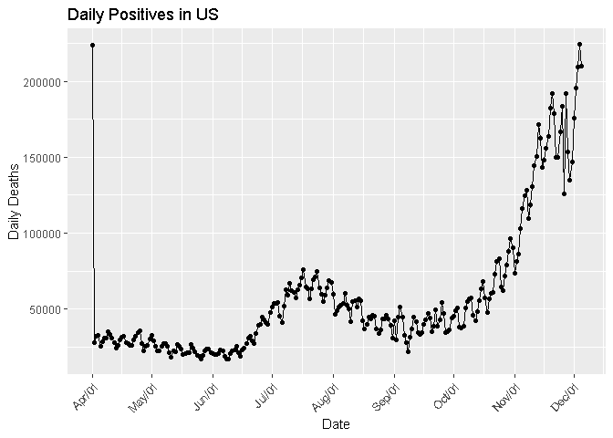

```r
#US Daily Death
ggplot(data=COVID_totals_final, aes(x=date, y=new_pos)) + geom_point() +
  geom_line() + labs(title='Daily Positives in US', x='Date', y='Daily Deaths')+
  scale_x_date(date_labels = "%b/%d", date_breaks = '1 month')+
  theme(axis.text.x = element_text(angle=45, hjust=1))
```

**Spectrum analysis and ACF plot**

See evidence for seasonality of 7; peaks at f = 0.14 and 0.28

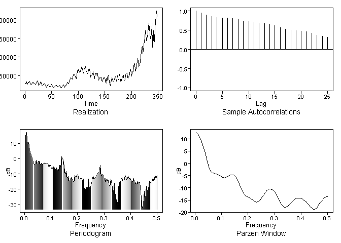

```
## $autplt
##  [1] 1.0000000 0.9494134 0.9019130 0.8628650 0.8335344 0.8154527 0.8161209
##  [8] 0.8135307 0.7864296 0.7415424 0.7238316 0.6972906 0.6806149 0.6741748
## [15] 0.6626941 0.6228906 0.5745525 0.5345778 0.5091340 0.4895603 0.4790216
## [22] 0.4622744 0.4232985 0.3784536 0.3433274 0.3180753
##
## $freq
##   [1] 0.004032258 0.008064516 0.012096774 0.016129032 0.020161290
##   [6] 0.024193548 0.028225806 0.032258065 0.036290323 0.040322581
##  [11] 0.044354839 0.048387097 0.052419355 0.056451613 0.060483871
##  [16] 0.064516129 0.068548387 0.072580645 0.076612903 0.080645161
##  [21] 0.084677419 0.088709677 0.092741935 0.096774194 0.100806452
##  [26] 0.104838710 0.108870968 0.112903226 0.116935484 0.120967742
##  [31] 0.125000000 0.129032258 0.133064516 0.137096774 0.141129032
##  [36] 0.145161290 0.149193548 0.153225806 0.157258065 0.161290323
```

[output cut: 71 more lines]

####Seasonal Transformation & AR Analysis

Because of the heavy wandering we want to $(1 - B)$ difference the data

We do see weak freq peaks at 0, .14 and .28 so we may want to apply a weak seasonal filter

```r
# (1 - B) difference
new_pos.d1 <- artrans.wge(new_pos.ts, c(1))
```

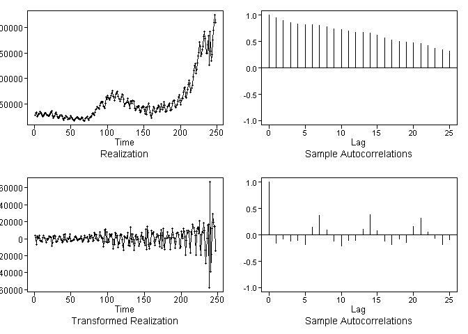

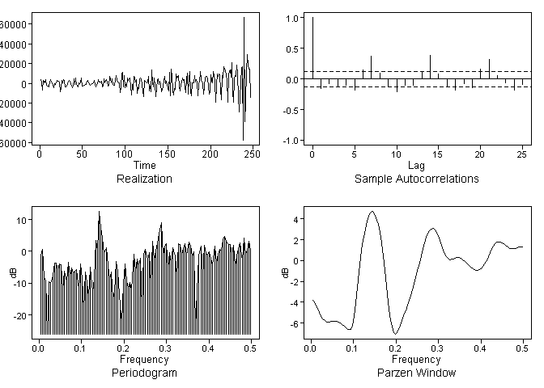

```
## $autplt
##  [1]  1.00000000 -0.15973203 -0.07993428 -0.11687917 -0.10130641
##  [6] -0.18872446  0.14133501  0.37856908  0.09748278 -0.11690416
## [11] -0.21441716 -0.09861593 -0.10137332  0.10654726  0.38306403
## [16]  0.08076257 -0.11729031 -0.17735718 -0.07627435 -0.13675166
## [21]  0.15859943  0.32404283  0.06074483 -0.06209423 -0.17600953
## [26] -0.08339529
##
## $freq
##   [1] 0.004048583 0.008097166 0.012145749 0.016194332 0.020242915
##   [6] 0.024291498 0.028340081 0.032388664 0.036437247 0.040485830
##  [11] 0.044534413 0.048582996 0.052631579 0.056680162 0.060728745
##  [16] 0.064777328 0.068825911 0.072874494 0.076923077 0.080971660
##  [21] 0.085020243 0.089068826 0.093117409 0.097165992 0.101214575
##  [26] 0.105263158 0.109311741 0.113360324 0.117408907 0.121457490
```

[output cut: 73 more lines]

```r
plotts.sample.wge(new_pos.d1 , arlimits = T)
```

**Factor Table**

The factor table for $(1 - B^{7})$ is listed below

> Factor Roots Abs Recip System Freq 1-1.0000B 1.0000 1.0000 0.0000 1+0.4450B+1.0000B^2 -0.2225+-0.9749i 1.0000 0.2857 1-1.2470B+1.0000B^2 0.6235+-0.7818i 1.0000 0.1429 1+1.8019B+1.0000B^2 -0.9010+-0.4339i 1.0000 0.4286

We overfit with p value of 12 and look at the factor table. When we overfit we see strong frequencies at 0, .14, .28

Again this is possibly due to data collection behavior.

```r
#overfit table
est.ar.wge(new_pos.d1 , p=12)
```

```
##
## Coefficients of Original polynomial:
## -0.4719 -0.1116 0.0991 0.1051 -0.0656 0.1557 0.4908 0.3981 0.0162 -0.3759 -0.1688 -0.2022
##
## Factor                 Roots                Abs Recip    System Freq
## 1-1.2261B+0.9830B^2    0.6236+-0.7927i      0.9915       0.1439
## 1+1.8091B+0.8796B^2   -1.0283+-0.2817i      0.9379       0.4574
## 1+0.3325B+0.8325B^2   -0.1997+-1.0776i      0.9124       0.2792
## 1-1.7653B+0.8053B^2    1.0961+-0.2010i      0.8974       0.0289
## 1+1.1972B+0.7769B^2   -0.7706+-0.8327i      0.8814       0.3688
## 1+0.1244B+0.4490B^2   -0.1386+-1.4860i      0.6700       0.2648
##
##
##
## Coefficients of Original polynomial:
## -0.4719 -0.1116 0.0991 0.1051 -0.0656 0.1557 0.4908 0.3981 0.0162 -0.3759 -0.1688 -0.2022
##
## Factor                 Roots                Abs Recip    System Freq
## 1-1.2261B+0.9830B^2    0.6236+-0.7927i      0.9915       0.1439
## 1+1.8091B+0.8796B^2   -1.0283+-0.2817i      0.9379       0.4574
## 1+0.3325B+0.8325B^2   -0.1997+-1.0776i      0.9124       0.2792
## 1-1.7653B+0.8053B^2    1.0961+-0.2010i      0.8974       0.0289
## 1+1.1972B+0.7769B^2   -0.7706+-0.8327i      0.8814       0.3688
## 1+0.1244B+0.4490B^2   -0.1386+-1.4860i      0.6700       0.2648
##
##
```

```
## $phi
##  [1] -0.47194885 -0.11164348  0.09914695  0.10512231 -0.06561215
##  [6]  0.15570872  0.49076984  0.39814556  0.01618041 -0.37585111
## [11] -0.16880867 -0.20219004
##
## $res
##   [1]   1397.62659   2121.10796  -3773.85421    645.30338    258.68505
##   [6]  -1903.15358   1027.54501  -3100.83832  -2778.57802  -1247.73254
##  [11]  -2937.25199  -1354.60741    300.61749   1450.62819    185.69406
##  [16]  -2135.43555   1330.73734    230.19572  -1133.17201  -1651.61795
##  [21]  -1651.81198   2206.80650   4380.63202  -5402.66017  -7419.77551
##  [26]  -2604.62977  -1188.10266    739.68586    854.41782  -2737.55168
##  [31]   -211.38715    571.10464   -516.62484  -2160.34092  -2591.96501
##  [36]  -3307.59057  -1990.73436   -803.55309   -900.49675   2729.38782
##  [41]  -2349.67924    313.85911  -2007.67552  -1245.06545   -890.45925
```

[output cut: 53 more lines]

Moderate seasonal filter $(1 - B^{7})$

Opting for the simpler BIC AR(8) model

```r
# (1 - B^7) difference
new_pos.d1s7 <- artrans.wge(new_pos.d1, c(0,0,0,0,0,0,1))
```

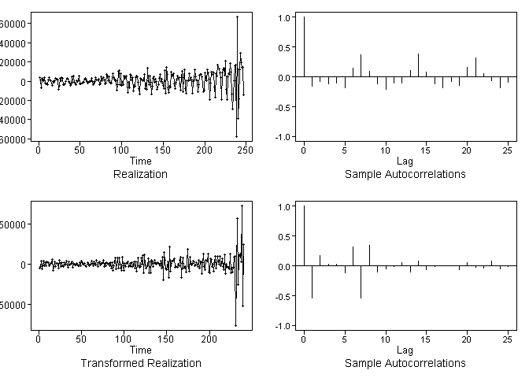

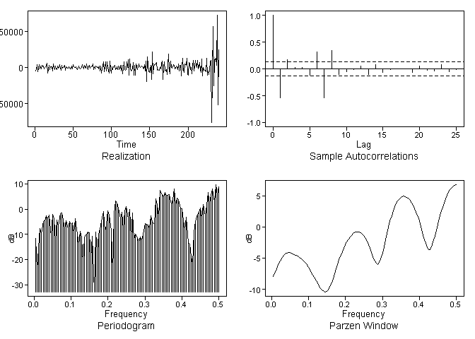

```
## $autplt
##  [1]  1.000000000 -0.539935878  0.173426120  0.026524417  0.023115992
##  [6] -0.111377161  0.319140268 -0.536909043  0.351775907 -0.098426211
## [11] -0.045956367 -0.009206881  0.048809316 -0.104121331  0.082004788
## [16] -0.063467736 -0.004601817  0.002778516  0.007894203 -0.064476692
## [21]  0.055856377 -0.021318566 -0.032410184  0.076220127 -0.055514651
## [26] -0.004186435
##
## $freq
##   [1] 0.004166667 0.008333333 0.012500000 0.016666667 0.020833333
##   [6] 0.025000000 0.029166667 0.033333333 0.037500000 0.041666667
##  [11] 0.045833333 0.050000000 0.054166667 0.058333333 0.062500000
##  [16] 0.066666667 0.070833333 0.075000000 0.079166667 0.083333333
##  [21] 0.087500000 0.091666667 0.095833333 0.100000000 0.104166667
##  [26] 0.108333333 0.112500000 0.116666667 0.120833333 0.125000000
```

[output cut: 70 more lines]

```r
plotts.sample.wge(new_pos.d1s7 , arlimits = T)
```

```r
# pick AIC for differenced data

aic5.wge(new_pos.d1s7, p=0:20, q=0:0) #picks AR(14)
```

```
## ---------WORKING... PLEASE WAIT...
##
##
## Error in aic calculation at 7 0
## Five Smallest Values of  aic
```

```
##       p    q        aic
## 15   14    0   17.70901
## 16   15    0   17.71376
## 18   17    0   17.71408
## 17   16    0   17.71811
## 19   18    0   17.72137
```

```r
aic5.wge(new_pos.d1s7, p=0:20, q=0:0, type='bic') #picks AR(8)
```

```
## ---------WORKING... PLEASE WAIT...
##
##
## Error in aic calculation at 7 0
## Five Smallest Values of  bic
```

```
##       p    q        bic
## 9     8    0   17.85945
## 10    9    0   17.88204
## 11   10    0   17.90143
## 12   11    0   17.92056
## 15   14    0   17.92655
```

Residuals do appear to be white noise

```r
#white noise test
new_pos.est <- est.ar.wge(new_pos.d1s7, p=8)
```

```
##
## Coefficients of Original polynomial:
## -0.4856 -0.0468 0.1757 0.1749 0.0143 0.0063 -0.6763 -0.2071
##
## Factor                 Roots                Abs Recip    System Freq
## 1+0.9745B             -1.0262               0.9745       0.5000
## 1+1.2049B+0.9437B^2   -0.6384+-0.8075i      0.9714       0.3565
## 1-1.6989B+0.8605B^2    0.9872+-0.4331i      0.9276       0.0658
## 1-0.2994B+0.8598B^2    0.1741+-1.0643i      0.9272       0.2242
## 1+0.3044B             -3.2848               0.3044       0.5000
##
##
##
## Coefficients of Original polynomial:
## -0.4856 -0.0468 0.1757 0.1749 0.0143 0.0063 -0.6763 -0.2071
##
## Factor                 Roots                Abs Recip    System Freq
## 1+0.9745B             -1.0262               0.9745       0.5000
## 1+1.2049B+0.9437B^2   -0.6384+-0.8075i      0.9714       0.3565
## 1-1.6989B+0.8605B^2    0.9872+-0.4331i      0.9276       0.0658
## 1-0.2994B+0.8598B^2    0.1741+-1.0643i      0.9272       0.2242
## 1+0.3044B             -3.2848               0.3044       0.5000
##
##
```

```r
new_pos.ar2 <- artrans.wge(new_pos.d1s7, new_pos.est$phi)
```

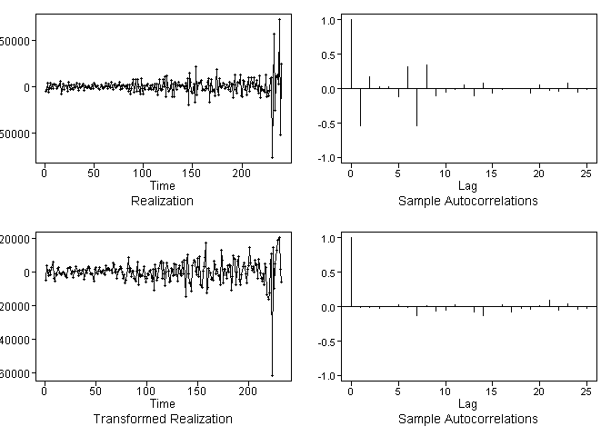

```r
var(new_pos.ar2)
```

```
## [1] 48121354
```

```r
mean(new_pos.ts)
```

```
## [1] 56731.35
```

**Validate white noise**

In both cases fails to reject H0

```r
ljung.wge(new_pos.ar2)$pval #FTR 0.6460292
```

```
## Obs -0.005290899 -0.01379364 -0.02772638 -0.002356698 0.03363506 -0.01378726 -0.1356712 0.020638 -0.06799467 -0.04771781 0.02585547 0.007850324 -0.08269021 -0.1347195 -0.0006970461 0.03473754 -0.07196822 -0.02783828 -0.03355642 0.01194102 0.08842413 -0.04809457 0.04445524 -0.03731472
```

```
## [1] 0.7631028
```

```r
ljung.wge(new_pos.ar2, K=48)$pval #FTR 0.9400058
```

```
## Obs -0.005290899 -0.01379364 -0.02772638 -0.002356698 0.03363506 -0.01378726 -0.1356712 0.020638 -0.06799467 -0.04771781 0.02585547 0.007850324 -0.08269021 -0.1347195 -0.0006970461 0.03473754 -0.07196822 -0.02783828 -0.03355642 0.01194102 0.08842413 -0.04809457 0.04445524 -0.03731472 -0.02739523 …
```

```
## [1] 0.9683811
```

#### ARIMA: Short Term Forecasts

Forecasting out 7 days

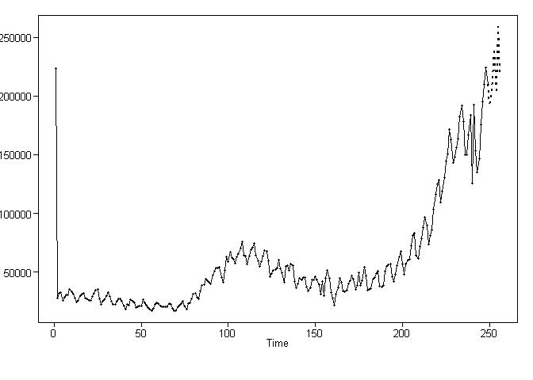

```r
# short-term forecasts of n = 7
fore.aruma.wge(COVID_totals_final$new_pos,
               phi=new_pos.est$phi,
               lambda = c(rep(0,6), 1),
               d=1,
               n.ahead=7,
               limits=F) -> new_pos.fcast7
```

**GGPLOT VISUALIZATION OF FORECASTS**

NOTE: Only doing this for **this one stat** so we have the code

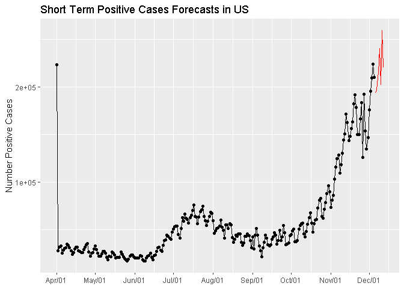

```r
#length of 242

dates <- seq(as.Date(COVID_totals_final$date[ length(COVID_totals_final$date) ]), by='day', length.out=8)[c(-1)]

forecasts <- data.frame(
  preds = new_pos.fcast7$f,
  upper = new_pos.fcast7$ul,
  lower = new_pos.fcast7$ll,
  dates = dates
  )

#Visualize
ggplot(data=COVID_totals_final, aes(x=date, y=new_pos)) +
  geom_line()+geom_point() + ggtitle('Short Term Positive Cases Forecasts in US')+
  xlab(NULL)+ylab('Number Positive Cases')+
  scale_x_date(date_labels = "%b/%d", date_breaks = '1 month')+
  #scale_y_continuous(breaks=seq(0,3000, 300))+
  geom_line(data=forecasts, aes(x=dates, y=preds), color='red')
```

**ASE**

ASE n of 20 for validation

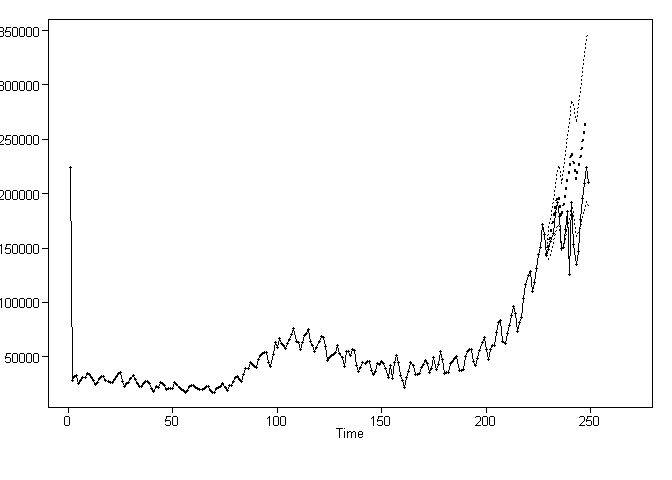

```r
#place holder for length
#NOTE since data is pulled live THIS WILL CHANGE
ase_length <- length(COVID_totals_final$new_pos)

# short-term forecasts of n = 7
# using FULL data NOT training
fore.aruma.wge(COVID_totals_final$new_pos,
               phi=new_pos.est$phi,
               lambda = c(rep(0,6), 1),
               d=1,
               n.ahead=20,
               lastn = T,
               limits=T) -> new_pos.ase20
```

```r
# Short-term ASE
mean(
  ( COVID_totals_final$new_pos[(ase_length-19):ase_length ] - new_pos.ase20$f )^2
  )
```

```
## [1] 2332613279
```

**Rolling Window ASE**

First we need to intially define the Window ASE Function. NOTE: this is a one-time snippet; we can re-use this function on later analysis

```r
#### ROLLING WINDOW ASE FUNCTION ####

Rolling_Window_ASE <- function(series, trainingSize, horizon = 1, s = 0, d = 0, phis = 0, thetas = 0, lambdas=0)
{
  trainingSize = trainingSize
  horizon = horizon
  ASEHolder = numeric()
  s = s
  d = s
  phis = phis
  thetas = thetas
  lambdas = lambdas


  for( i in 1:(length(series)-(trainingSize + horizon) + 1))
  {

    forecasts = fore.aruma.wge(
      series[i:(i+(trainingSize-1))],
      phi = phis,
      theta = thetas,
      s = s,
      d = d,
      lambda = lambdas,
      n.ahead = horizon,
      lastn = T,
      plot=F)

    ASE <- mean((series[(trainingSize+i):(trainingSize+ i + (horizon) - 1)] - forecasts$f)^2)

    ASEHolder[i] <- ASE

  }

  WindowedASE = mean(ASEHolder)

  print("The Summary Statistics for the Rolling Window ASE Are:")
  print(summary(ASEHolder))
  print(paste("The Rolling Window ASE is: ",WindowedASE))
  return(WindowedASE)
}
```

```r
Rolling_Window_ASE(
  series = COVID_totals_final$new_pos,
  trainingSize = 50,
  horizon = 20,
  phis = new_pos.est$phi,
  lambdas = c(rep(0,6), 1),
  d=1
  )
```

```
## [1] "The Summary Statistics for the Rolling Window ASE Are:"
##      Min.   1st Qu.    Median      Mean   3rd Qu.      Max.
## 2.742e+07 1.293e+08 5.196e+08 1.761e+09 1.476e+09 1.214e+10
## [1] "The Rolling Window ASE is:  1761217369.44725"
```

```
## [1] 1761217369
```

#### ARIMA: Long-Term Forecast

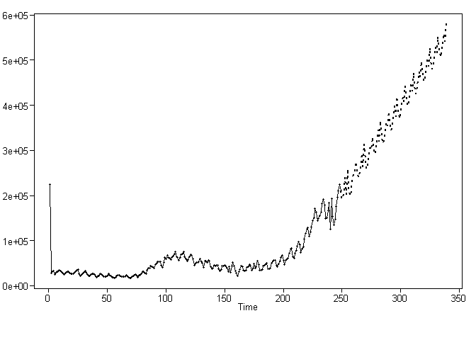

```r
# short-term forecasts of n = 90
fore.aruma.wge(COVID_totals_final$new_pos,
               phi=new_pos.est$phi,
               lambda = c(rep(0,6), 1),
               d=1,
               n.ahead=90,
               limits=F) -> new_pos.fcast90
```

**GGPLOT VISUALIZATION OF FORECASTS**

NOTE: Only doing this for **this one stat** so we have the code

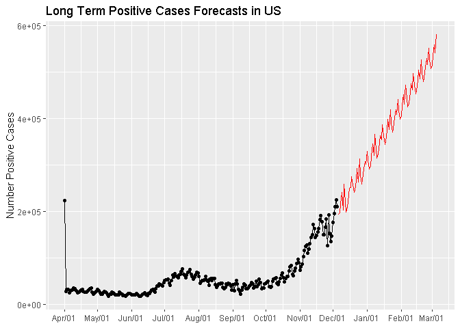

```r
#length of 242
#length(COVID_totals_final$date)

dates <- seq(as.Date(COVID_totals_final$date[ length(COVID_totals_final$date) ]), by='day', length.out=91)[c(-1)]

forecasts <- data.frame(
  preds = new_pos.fcast90$f,
  upper = new_pos.fcast90$ul,
  lower = new_pos.fcast90$ll,
  dates = dates
  )

#Visualize
ggplot(data=COVID_totals_final, aes(x=date, y=new_pos)) +
  geom_line()+geom_point() + ggtitle('Long Term Positive Cases Forecasts in US')+
  xlab(NULL)+ylab('Number Positive Cases')+
  scale_x_date(date_labels = "%b/%d", date_breaks = '1 month')+
  #scale_y_continuous(breaks=seq(0,3000, 300))+
  geom_line(data=forecasts, aes(x=dates, y=preds), color='red')
```

**ASE**

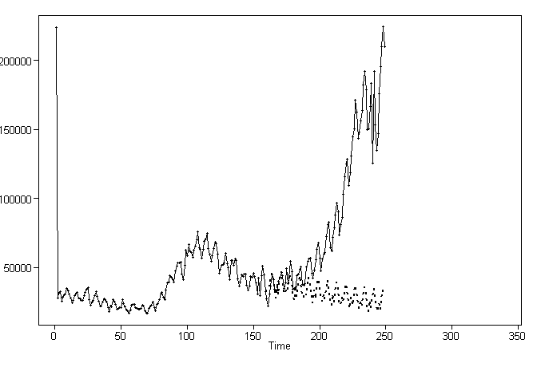

```r
#place holder for length
#NOTE since data is pulled live THIS WILL CHANGE
ase_length <- length(COVID_totals_final$new_pos)

# short-term forecasts of n = 7
# using FULL data NOT training
fore.aruma.wge(COVID_totals_final$new_pos,
               phi=new_pos.est$phi,
               lambda = c(rep(0,6), 1),
               d=1,
               n.ahead=90,
               lastn = T,
               limits=F) -> new_pos.ase90
```

```r
# Short-term ASE

mean(
  ( COVID_totals_final$new_pos[(ase_length-89):ase_length ] - new_pos.ase90$f )^2
  )
```

```
## [1] 6799990968
```

**Rolling Window ASE**

```r
Rolling_Window_ASE(
  series = COVID_totals_final$new_pos,
  trainingSize = 50,
  horizon = 20,
  phis = new_pos.est$phi,
  lambdas = c(rep(0,6), 1),
  d=1
  )
```

```
## [1] "The Summary Statistics for the Rolling Window ASE Are:"
##      Min.   1st Qu.    Median      Mean   3rd Qu.      Max.
## 2.742e+07 1.293e+08 5.196e+08 1.761e+09 1.476e+09 1.214e+10
## [1] "The Rolling Window ASE is:  1761217369.44725"
```

```
## [1] 1761217369
```

### Univariate MLP Model

####Short-Term Model

MLP MODEL STATS

```r
new_pos.mlp <- mlp(
  new_pos.ts,
  difforder = c(1,7),
  allow.det.season = F,
  reps = 50,
  comb = "median")

new_pos.mlp
```

```
## MLP fit with 5 hidden nodes and 50 repetitions.
## Series modelled in differences: D1D7.
## Univariate lags: (1,2,3,4)
## Forecast combined using the median operator.
## MSE: 40945930.5074.
```

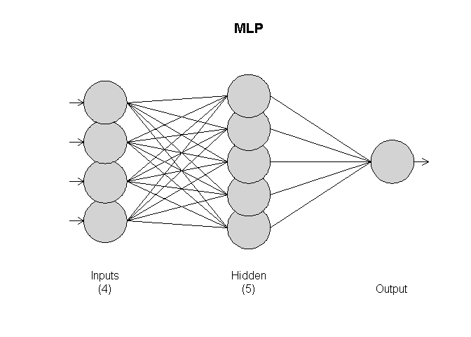

```r
# Visualize the Neural Network
plot(new_pos.mlp)
```

**MLP Short-Term Predictions**

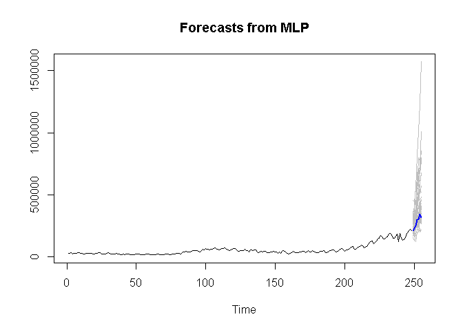

```r
#MLP Forecast
new_pos.mlp.f7 <- forecast(new_pos.mlp, h = 7 )
plot(new_pos.mlp.f7)
```

BECAUSE THE GRAPH IS HARD TO READ WITH THE EXTREME OUTLIER

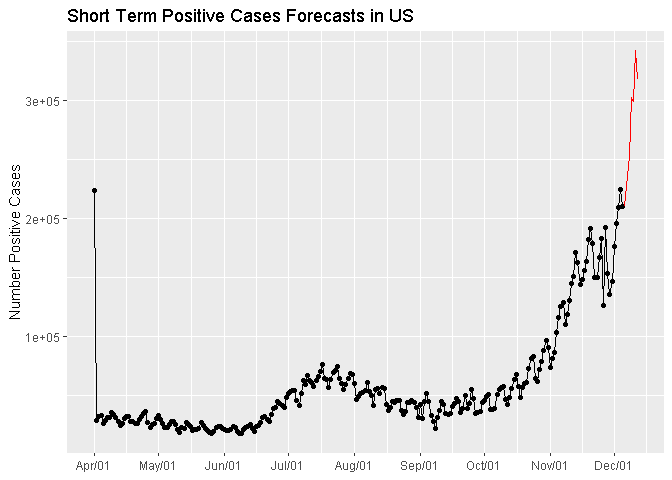

```r
dates <- seq(as.Date(COVID_totals_final$date[ length(COVID_totals_final$date) ]), by='day', length.out=8)[c(-1)]

forecasts <- data.frame(
  preds =  as.vector(new_pos.mlp.f7$mean) ,
  dates = dates
  )

#Visualize
ggplot(data=COVID_totals_final, aes(x=date, y=new_pos)) +
  geom_line()+geom_point() + ggtitle('Short Term Positive Cases Forecasts in US')+
  xlab(NULL)+ylab('Number Positive Cases')+
  scale_x_date(date_labels = "%b/%d", date_breaks = '1 month')+
  #scale_y_continuous(breaks=seq(0,3000, 300))+
  geom_line(data=forecasts, aes(x=dates, y=preds), color='red')
```

**MLP Short-Term ASE**

Validating on a hold out of 20

```r
mlp_length <- length(COVID_totals_final$new_pos)

# TRAIN / TEST SPLIT
# split for pred 20
COVID_totals_final$new_pos[1:(mlp_length-20)] %>%
  as.ts() -> new_pos.train


COVID_totals_final$new_pos[(mlp_length-19):mlp_length] %>%
  as.ts() -> new_pos.test
```

```r
#ASE MLP Model
new_pos.ase.mlp <- mlp(
  new_pos.train,
  difforder = c(1,7),
  allow.det.season = F,
  reps = 50,
  comb = "median")
new_pos.ase.mlp
```

```
## MLP fit with 5 hidden nodes and 50 repetitions.
## Series modelled in differences: D1D7.
## Univariate lags: (1,2)
## Forecast combined using the median operator.
## MSE: 24846059.5263.
```

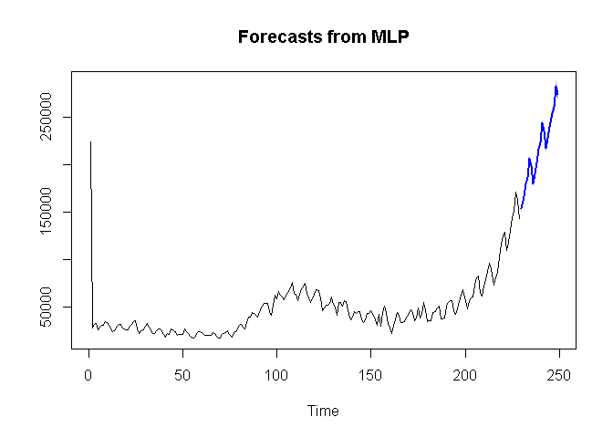

```r
new_pos.mlp.ase.f <- forecast(new_pos.ase.mlp, h = length(new_pos.test) )

plot(new_pos.mlp.ase.f)
```

```r
#ASE
mean(( as.vector(new_pos.test) - as.vector(new_pos.mlp.ase.f$mean) )^2)
```

```
## [1] 2797151155
```

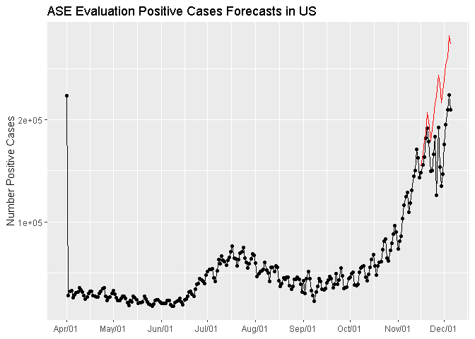

```r
dates <- seq(as.Date(COVID_totals_final$date[ length(COVID_totals_final$date)-20 ]), by='day', length.out=21)[c(-1)]

forecasts <- data.frame(
  preds = new_pos.mlp.ase.f$mean,
  dates = dates
  )

#Visualize
ggplot(data=COVID_totals_final, aes(x=date, y=new_pos)) +
  geom_line()+geom_point() + ggtitle('ASE Evaluation Positive Cases Forecasts in US')+
  xlab(NULL)+ylab('Number Positive Cases')+
  scale_x_date(date_labels = "%b/%d", date_breaks = '1 month')+
  #scale_y_continuous(breaks=seq(0,3000, 300))+
  geom_line(data=forecasts, aes(x=dates, y=preds), color='red')
```

### Short-Term Univariate Ensemble

We average the predictions from the ARIMA and the MLP

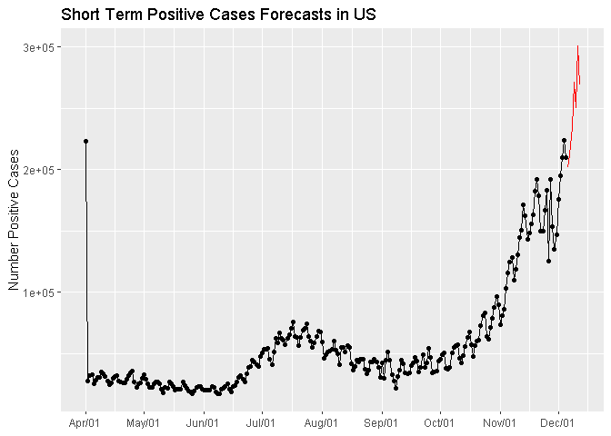

```r
dates <- seq(as.Date(COVID_totals_final$date[ length(COVID_totals_final$date) ]), by='day', length.out=8)[c(-1)]

forecasts <- data.frame(
  preds = (new_pos.fcast7$f + as.numeric(new_pos.mlp.f7[[2]]) )/2,
  dates = dates
  )

#Visualize
ggplot(data=COVID_totals_final, aes(x=date, y=new_pos)) +
  geom_line()+geom_point() + ggtitle('Short Term Positive Cases Forecasts in US')+
  xlab(NULL)+ylab('Number Positive Cases')+
  scale_x_date(date_labels = "%b/%d", date_breaks = '1 month')+
  #scale_y_continuous(breaks=seq(0,3000, 300))+
  geom_line(data=forecasts, aes(x=dates, y=preds), color='red')
```

```r
#ASE

mean(
  ( (new_pos.ase20$f + as.vector(new_pos.mlp.ase.f$mean) )/2 - as.vector(new_pos.test))^2
)
```

```
## [1] 2555695048
```

####Long-Term Forecast

**MLP Long-Term Predictions**

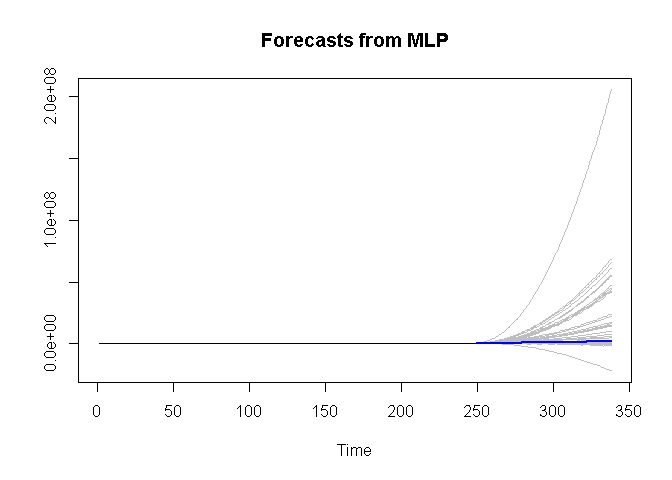

```r
#MLP Forecast
new_pos.mlp.f90 <- forecast(new_pos.mlp, h = 90 )
plot(new_pos.mlp.f90)
```

BECAUSE THE GRAPH IS HARD TO READ WITH THE EXTREME OUTLIER

Predictions are pretty terrible, with the upward trend continuing indefinately

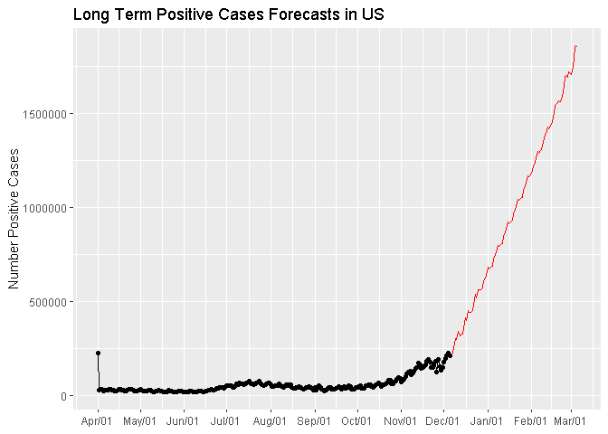

```r
dates <- seq(as.Date(COVID_totals_final$date[ length(COVID_totals_final$date) ]), by='day', length.out=91)[c(-1)]

forecasts <- data.frame(
  preds =  as.vector(new_pos.mlp.f90$mean) ,
  dates = dates
  )

#Visualize
ggplot(data=COVID_totals_final, aes(x=date, y=new_pos)) +
  geom_line()+geom_point() + ggtitle('Long Term Positive Cases Forecasts in US')+
  xlab(NULL)+ylab('Number Positive Cases')+
  scale_x_date(date_labels = "%b/%d", date_breaks = '1 month')+
  #scale_y_continuous(breaks=seq(0,3000, 300))+
  geom_line(data=forecasts, aes(x=dates, y=preds), color='red')
```

**MLP ASE**

```r
#ASE MLP Model
new_pos.ase.mlp <- mlp(
  new_pos.train,
  difforder = c(1,7),
  allow.det.season = F,
  reps = 50,
  comb = "mean")
new_pos.ase.mlp
```

```
## MLP fit with 5 hidden nodes and 50 repetitions.
## Series modelled in differences: D1D7.
## Univariate lags: (1,2)
## Forecast combined using the mean operator.
## MSE: 24893728.4687.
```

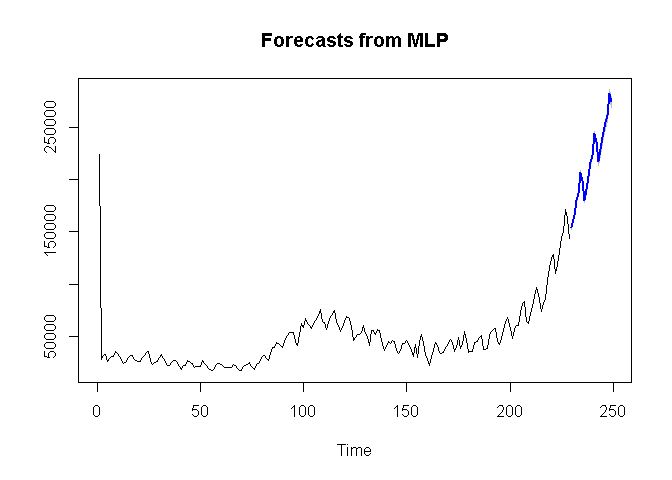

```r
new_pos.mlp.ase.f <- forecast(new_pos.ase.mlp, h = length(new_pos.test) )

plot(new_pos.mlp.ase.f)
```

```r
#ASE
mean(( as.vector(new_pos.test) - as.vector(new_pos.mlp.ase.f$mean) )^2)
```

```
## [1] 2814337000
```

###Long-Term Univariate Ensemble

We average the predictions from the ARUMA and the MLP

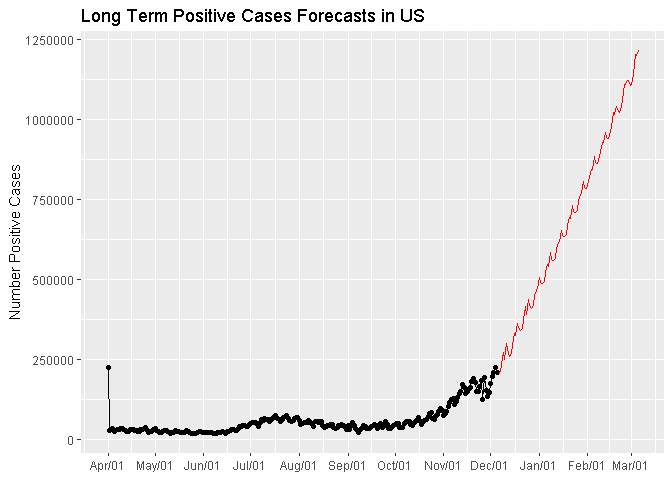

```r
dates <- seq(as.Date(COVID_totals_final$date[ length(COVID_totals_final$date) ]), by='day', length.out=91)[c(-1)]

forecasts <- data.frame(
  preds = (new_pos.fcast90$f + as.vector(new_pos.mlp.f90$mean) )/2,
  dates = dates
  )

#Visualize
ggplot(data=COVID_totals_final, aes(x=date, y=new_pos)) +
  geom_line()+geom_point() + ggtitle('Long Term Positive Cases Forecasts in US')+
  xlab(NULL)+ylab('Number Positive Cases')+
  scale_x_date(date_labels = "%b/%d", date_breaks = '1 month')+
  #scale_y_continuous(breaks=seq(0,3000, 300))+
  geom_line(data=forecasts, aes(x=dates, y=preds), color='red')
```

```r
#ASE
#mean(  ((new_pos.ase20$f + as.vector(new_pos.mlp.ase.f$mean))/2 - new_pos.test)^2 )
```

## Multivariate Analysis - US National - Daily Positives

Now we include other explanatory variables. * Particular days of the week, specifically weekdays vs weekends * Hospitalization

### US: Weekday vs Weekend

```r
# populate "is_weekend" column
COVID_totals_final$is_weekend <- 'Weekday'
# identify
COVID_totals_final[COVID_totals_final$day_of_week %in% c("Saturday","Sunday"), 'is_weekend'] <- 'Weekend'


COVID_totals_final$is_weekend <- factor(
  COVID_totals_final$is_weekend,
  levels=c('Weekday', 'Weekend')
  )

#confirm
COVID_totals_final %>% dplyr::select(date, day_of_week, is_weekend) %>% tail(10)
```

```
## # A tibble: 10 x 3
##    date       day_of_week is_weekend
##    <date>     <fct>       <fct>
##  1 2020-11-26 Thursday    Weekday
##  2 2020-11-27 Friday      Weekday
##  3 2020-11-28 Saturday    Weekend
##  4 2020-11-29 Sunday      Weekend
##  5 2020-11-30 Monday      Weekday
##  6 2020-12-01 Tuesday     Weekday
##  7 2020-12-02 Wednesday   Weekday
##  8 2020-12-03 Thursday    Weekday
##  9 2020-12-04 Friday      Weekday
## 10 2020-12-05 Saturday    Weekend
```

```r
###MLR using weekend
#holdout last 20 for ASE
#ggplot(COVID_US_final, aes(x=hospital_sum, y=new_pos)) + geom_point()
```

####Exploration: Weekend vs Weekday

**Weekday vs Weekend Boxplots**

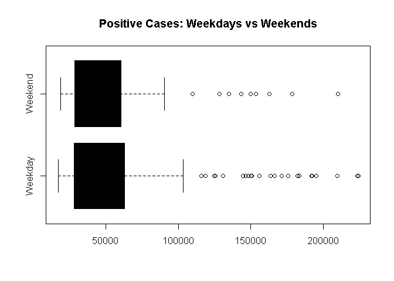

```r
boxplot(
  COVID_totals_final$new_pos ~ COVID_totals_final$is_weekend,
  horizontal = T, col = COVID_totals_final$is_weekend,
  main = "Positive Cases: Weekdays vs Weekends")
```

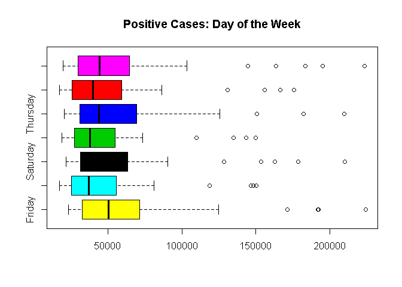

```r
boxplot(
  COVID_totals_final$new_pos ~ COVID_totals_final$day_of_week,
  horizontal = T, col = COVID_totals_final$day_of_week,
  main = "Positive Cases: Day of the Week")
```

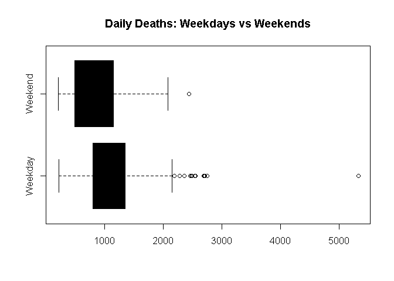

```r
boxplot(
  COVID_totals_final$new_death ~ COVID_totals_final$is_weekend,
  horizontal = T, col = COVID_totals_final$is_weekend,
  main = "Daily Deaths: Weekdays vs Weekends")
```

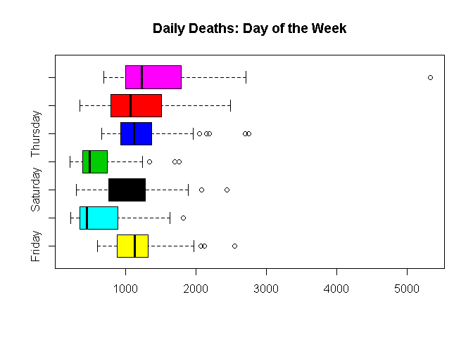

```r
boxplot(
  COVID_totals_final$new_death ~ COVID_totals_final$day_of_week,
  horizontal = T, col = COVID_totals_final$day_of_week,
  main = "Daily Deaths: Day of the Week")
```

**Weekday vs Weekend Histograms**